# Project 1: Trump, Twitter, and Text

In this project, we will work with the Twitter API in order to analyze Donald Trump's tweets.

**The project is due 11:59pm Sunday, October 20**

If you find yourself getting frustrated or stuck on one problem for too long, we suggest coming into office hours and working with friends in the class.

```python
# Run this cell to set up your notebook
import csv
import numpy as np
import pandas as pd
import matplotlib.pyplot as plt
import zipfile
import json

# Ensure that Pandas shows at least 280 characters in columns, so we can see full tweets
pd.set_option('max_colwidth', 280)

%matplotlib inline
plt.style.use('fivethirtyeight')
import seaborn as sns
sns.set()
sns.set_context("talk")
import re
```

## Getting the data

The starting point and a key aspect of any data science project is getting the data. To get Twitter data, Twitter conveniently provides a developer API using which we can scrape data. More on that will follow in the coming discussions!

For now, we've made life easier for you by providing the data.

Start by running the following cells, which will download and then load Donald Trump's most recent tweets.

```python
# Download the dataset
from utils import fetch_and_cache
data_url = 'https://cims.nyu.edu/~policast/recent_tweets.json'
file_name = 'realdonaldtrump_recent_tweets.json'

dest_path = fetch_and_cache(data_url=data_url, file=file_name)
print(f'Located at {dest_path}')
```

```
Using version already downloaded: Mon Oct  7 20:53:49 2019
MD5 hash of file: 216176fb098cd5d6b40b373b98bd3e6d
Located at data/realdonaldtrump_recent_tweets.json
```

```python
def load_tweets(path):
    """Loads tweets that have previously been saved.

    Calling load_tweets(path) after save_tweets(tweets, path)
    will produce the same list of tweets.

    Args:
        path (str): The place where the tweets were be saved.

    Returns:
        list: A list of Dictionary objects, each representing one tweet."""

    with open(path, "rb") as f:
        import json
        return json.load(f)
```

```python
trump_tweets = load_tweets(dest_path)
```

If everything is working correctly correctly this should load roughly the last 3000 tweets by `realdonaldtrump`.

```python
assert 2000 <= len(trump_tweets) <= 4000
```

### Question 1

We are limited to how many tweets we can download. In what month is the oldest tweet from Trump?

```python
# Enter the number of the month of the oldest tweet (e.g. 1 for January)
### BEGIN SOLUTION
oldest_month = 10
trump_tweets[-1]
# I'm assuming the list is organized, and I checked trump_tweets[0] which was in 2018, so I figured it collected backwards
### END SOLUTION
```

[output not shown]

[output cut: 14 more lines]

[output not shown]

```python
### BEGIN HIDDEN TESTS
assert oldest_month > 9
assert oldest_month < 12
### END HIDDEN TESTS
```

**IMPORTANT! PLEASE READ**

What if we want to access Donald Trump's old tweets?  
Unfortunately, you cannot download old tweets using the public Twitter APIs. Fortunately, we have a snapshot of earlier tweets of Donald Trump that we can combine with the newer data that you downloaded

We will again use the `fetch_and_cache` utility to download the dataset.

```python
# Download the dataset
from utils import fetch_and_cache
data_url = 'https://cims.nyu.edu/~policast/old_trump_tweets.json.zip'
file_name = 'old_trump_tweets.json.zip'

dest_path = fetch_and_cache(data_url=data_url, file=file_name)
print(f'Located at {dest_path}')
```

```
Using version already downloaded: Mon Oct  7 20:53:49 2019
MD5 hash of file: b6e33874de91d1a40207cdf9f9b51a09
Located at data/old_trump_tweets.json.zip
```

Finally, we we will load the tweets directly from the compressed file without decompressing it first.

```python
my_zip = zipfile.ZipFile(dest_path, 'r')
with my_zip.open("old_trump_tweets.json", "r") as f:
    old_trump_tweets = json.load(f)
```

This data is formatted identically to the recent tweets we just downloaded:

```python
pprint(old_trump_tweets[0])
```

```
Pretty printing has been turned OFF
```

As a dictionary we can also list the keys:

```python
old_trump_tweets[0].keys()
```

```
dict_keys(['created_at', 'id', 'id_str', 'text', 'truncated', 'entities', 'extended_entities', 'source', 'in_reply_to_status_id', 'in_reply_to_status_id_str', 'in_reply_to_user_id', 'in_reply_to_user_id_str', 'in_reply_to_screen_name', 'user', 'geo', 'coordinates', 'place', 'contributors', 'is_quote…
```

Since we're giving you a zipfile of old tweets, you may wonder why we didn't just give you a zipfile of ALL tweets and save you the trouble of creating a Twitter developer account. The reason is that we wanted you to see what it's like to collect data from the real world on your own. It can be a pain!

And for those of you that never got your developer accounts, you can see it can be even more of a pain that we expected. Sorry to anybody that wasted a bunch of time trying to get things working.

### Question 2

Merge the `old_trump_tweets` and the `trump_tweets` we downloaded from twitter into one giant list of tweets.

**Important:** There may be some overlap so be sure to eliminate duplicate tweets.  
**Hint:** the `id` of a tweet is always unique.

```python
### BEGIN SOLUTION

all_tweets = old_trump_tweets + trump_tweets
#all_tweets = list(set([all_tweets['id']]))
# i removed the duplicates from the dataframe instead of from the list, for efficiency
#TODO
### END SOLUTION
```

```python
assert len(all_tweets) > len(trump_tweets)
assert len(all_tweets) > len(old_trump_tweets)
### BEGIN HIDDEN TESTS
assert len(set([t['id'] for t in all_tweets])) <= len([t['id'] for t in all_tweets])
### END HIDDEN TESTS
```

### Question 3

Construct a DataFrame called `trump` containing all the tweets stored in `all_tweets`. The index of the dataframe should be the ID of each tweet (looks something like `907698529606541312`). It should have these columns:

- `time`: The time the tweet was created encoded as a datetime object. (Use `pd.to_datetime` to encode the timestamp.)
- `source`: The source device of the tweet.
- `text`: The text of the tweet.
- `retweet_count`: The retweet count of the tweet.

Finally, **the resulting dataframe should be sorted by the index.**

**Warning:** *Some tweets will store the text in the `text` field and other will use the `full_text` field.*

```python
all_tweets[0].keys()
```

```
dict_keys(['created_at', 'id', 'id_str', 'text', 'truncated', 'entities', 'extended_entities', 'source', 'in_reply_to_status_id', 'in_reply_to_status_id_str', 'in_reply_to_user_id', 'in_reply_to_user_id_str', 'in_reply_to_screen_name', 'user', 'geo', 'coordinates', 'place', 'contributors', 'is_quote…
```

```python
### BEGIN SOLUTION
trump = pd.DataFrame(all_tweets, columns=["created_at", "id", "text", "full_text", "retweet_count","favorite_count","source"])
trump = trump.drop_duplicates(subset=['id'], keep='first')
trump.set_index('id', inplace=True)
trump = trump.replace(np.nan, '', regex=True)
trump['text'] = trump["text"].map(str) + trump["full_text"].map(str)
trump = trump.drop('full_text', 1)
trump['time'] = pd.to_datetime(trump['created_at'])
trump = trump.drop('created_at', 1)
trump.sort_values('id')
#TODO
### END SOLUTION
```

| id | text | retweet_count | favorite_count | source | time |
| --- | --- | --- | --- | --- | --- |
| 690171032150237184 | "@bigop1: @realDonaldTrump @SarahPalinUSA https://t.co/3kYQGqeVyD" | 1059 | 2485 | <a href="http://twitter.com/download/android" rel="nofollow">Twitter for Android</a> | 2016-01-21 13:56:11+00:00 |
| 690171403388104704 | "@AmericanAsPie: @glennbeck @SarahPalinUSA Remember when Glenn gave out gifts to ILLEGAL ALIENS at crossing the border? Me too!" | 1339 | 3306 | <a href="http://twitter.com/download/android" rel="nofollow">Twitter for Android</a> | 2016-01-21 13:57:39+00:00 |
| 690173226341691392 | So sad that @CNN and many others refused to show the massive crowd at the arena yesterday in Oklahoma. Dishonest reporting! | 2006 | 5936 | <a href="http://twitter.com/download/android" rel="nofollow">Twitter for Android</a> | 2016-01-21 14:04:54+00:00 |
| 690176882055114758 | Sad sack @JebBush has just done another ad on me, with special interest money, saying I won't beat Hillary - I WILL. But he can't beat me. | 2266 | 6569 | <a href="http://twitter.com/download/android" rel="nofollow">Twitter for Android</a> | 2016-01-21 14:19:26+00:00 |
| 690180284189310976 | Low energy candidate @JebBush has wasted $80 million on his failed presidential campaign. Millions spent on me. He should go home and relax! | 2886 | 8544 | <a href="http://twitter.com/download/android" rel="nofollow">Twitter for Android</a> | 2016-01-21 14:32:57+00:00 |
| 690271688127213568 | New Day on CNN treats me very badly. @AlisynCamerota is a disaster. Not going to watch anymore. | 1429 | 4544 | <a href="http://twitter.com/download/iphone" rel="nofollow">Twitter for iPhone</a> | 2016-01-21 20:36:09+00:00 |
| 690272687168458754 | Happy birthday to my friend, the great @jacknicklaus - a totally special guy! | 1053 | 4379 | <a href="http://twitter.com/download/android" rel="nofollow">Twitter for Android</a> | 2016-01-21 20:40:07+00:00 |
| 690313350278819840 | Thank you, Iowa! #Trump2016 https://t.co/ryhEheTLqN | 2329 | 5984 | <a href="http://twitter.com/download/iphone" rel="nofollow">Twitter for iPhone</a> | 2016-01-21 23:21:42+00:00 |
| 690315202261155840 | Thank you! #Trump2016 https://t.co/pcdmyIO1Zt | 1463 | 4326 | <a href="http://twitter.com/download/iphone" rel="nofollow">Twitter for iPhone</a> | 2016-01-21 23:29:04+00:00 |
| 690315366564626433 | Thank you, New Hampshire!\n#Trump2016 https://t.co/TG9oZKly4l | 1761 | 4916 | <a href="http://twitter.com/download/iphone" rel="nofollow">Twitter for iPhone</a> | 2016-01-21 23:29:43+00:00 |
| 690315667636023296 | #Trump2016 #MakeAmericaGreatAgain https://t.co/vfUwGIGjN4 | 2217 | 5788 | <a href="http://twitter.com/download/iphone" rel="nofollow">Twitter for iPhone</a> | 2016-01-21 23:30:55+00:00 |
| 690336644281581568 | Why does @Greta have a fired Bushy like dummy, John Sununu on- spewing false info? I will beat Hillary by a lot, she wants no part of Trump. | 1576 | 5188 | <a href="http://twitter.com/download/iphone" rel="nofollow">Twitter for iPhone</a> | 2016-01-22 00:54:16+00:00 |
| 690337376061788161 | Thank you, Iowa! #FITN #IACaucus\n#MakeAmericaGreatAgain #Trump2016 https://t.co/wVJldvTSag | 2422 | 5626 | <a href="http://twitter.com/download/iphone" rel="nofollow">Twitter for iPhone</a> | 2016-01-22 00:57:10+00:00 |
| 690382564494839809 | National Review is a failing publication that has lost it's way. It's circulation is way down w its influence being at an all time low. Sad! | 2187 | 6062 | <a href="http://twitter.com/download/iphone" rel="nofollow">Twitter for iPhone</a> | 2016-01-22 03:56:44+00:00 |
| 690382619213742082 | Very few people read the National Review because it only knows how to criticize, but not how to lead. | 1817 | 5069 | <a href="http://twitter.com/download/iphone" rel="nofollow">Twitter for iPhone</a> | 2016-01-22 03:56:57+00:00 |
| 690382722162913280 | The late, great, William F. Buckley would be ashamed of what had happened to his prize, the dying National Review! | 2236 | 5473 | <a href="http://twitter.com/download/iphone" rel="nofollow">Twitter for iPhone</a> | 2016-01-22 03:57:22+00:00 |
| 690404308010057728 | RT @williebosshog: Make America Great Again! #Trump2016 https://t.co/1h5j4DZDgy | 9144 | 0 | <a href="http://twitter.com/download/iphone" rel="nofollow">Twitter for iPhone</a> | 2016-01-22 05:23:08+00:00 |
| 690528062190944256 | Ted Cruz complains about my views on eminent domain, but without it we wouldn't have roads, highways, airports, schools or even pipelines. | 1595 | 4264 | <a href="http://twitter.com/download/android" rel="nofollow">Twitter for Android</a> | 2016-01-22 13:34:54+00:00 |
| 690528407117889538 | "@realOllieTaylor: Isn't it time we had a president? Let goofy Glen keep Canada Cruz who can't win. The American people have Trump!" | 909 | 3005 | <a href="http://twitter.com/download/android" rel="nofollow">Twitter for Android</a> | 2016-01-22 13:36:16+00:00 |
| 690528526181601281 | "@BornToBeGOP: @realDonaldTrump No sleep for the #TrumpTrain!" | 676 | 2489 | <a href="http://twitter.com/download/android" rel="nofollow">Twitter for Android</a> | 2016-01-22 13:36:44+00:00 |
| 690529122326413314 | "@NeilTurner_: @realDonaldTrump https://t.co/uvn95NB6M0 With your help we can #MakeAmericaGreatAgain! #VoteTrump" | 773 | 2224 | <a href="http://twitter.com/download/android" rel="nofollow">Twitter for Android</a> | 2016-01-22 13:39:06+00:00 |
| 690529690205818880 | #TedCruz eligibility to be President not settled law, says Cruz' Constitutional Law Professor, #LaurenceTribe https://t.co/GWKoJsBINZ" | 753 | 2125 | <a href="http://twitter.com/download/android" rel="nofollow">Twitter for Android</a> | 2016-01-22 13:41:22+00:00 |
| 690530164711624705 | "@TruBluMajority: #laurencetribe calls Cruz "constitutional hypocrite" on @WBUR https://t.co/qRFINtcJlX @pbsgwen @charlierose @jaketapper | 637 | 1940 | <a href="http://twitter.com/download/android" rel="nofollow">Twitter for Android</a> | 2016-01-22 13:43:15+00:00 |
| 690532959363866625 | Highly respected Constitutional law professor Mary Brigid McManamon has just stated, "Ted Cruz is not eligible to be President." Big problem | 1937 | 4683 | <a href="http://twitter.com/download/android" rel="nofollow">Twitter for Android</a> | 2016-01-22 13:54:21+00:00 |
| 690534215478173697 | "@D: #MaryBrigidMcManamon, Washington Post: Constitutionally speaking, #Cruz simply isn’t eligible to be president https://t.co/DBtTgsC1il" | 875 | 2357 | <a href="http://twitter.com/download/android" rel="nofollow">Twitter for Android</a> | 2016-01-22 13:59:21+00:00 |
| 690534576066719744 | "@CyberCiety: #MaryBrigidMcManamon clarified how #CommonLaw is used to interpret meaning of #NaturalBorn #TedCruz https://t.co/5y6SZrTdGr" | 799 | 2348 | <a href="http://twitter.com/download/android" rel="nofollow">Twitter for Android</a> | 2016-01-22 14:00:47+00:00 |
| 690537121916923904 | "@MiamiNewTimes: Poll: Trump has more support in Florida than Rubio and Bush combined. https://t.co/uvH2BKQRHf https://t.co/2tvIaa2aFr" | 1738 | 4160 | <a href="http://twitter.com/download/android" rel="nofollow">Twitter for Android</a> | 2016-01-22 14:10:54+00:00 |
| 690540484154896384 | The failing @NRO National Review Magazine has just been informed by the Republican National Committee that they cannot participate in debate | 2116 | 5374 | <a href="http://twitter.com/download/android" rel="nofollow">Twitter for Android</a> | 2016-01-22 14:24:15+00:00 |
| 690560125916975104 | After spending $89 million, @JebBush is at the bottom of the barrel in polls. He is ashamed to use the name "Bush" in ads. Low energy guy! | 1661 | 4835 | <a href="http://twitter.com/download/android" rel="nofollow">Twitter for Android</a> | 2016-01-22 15:42:18+00:00 |
| 690560942430523392 | "@Lisa_Milicaj: Truth be told, I never heard of The National Review until they "tried" to declare war on you. No worries, you got my vote!" | 1110 | 3647 | <a href="http://twitter.com/download/android" rel="nofollow">Twitter for Android</a> | 2016-01-22 15:45:33+00:00 |
| ... | ... | ... | ... | ... | ... |
| 1051319975795933184 | Congratulations to Tucker Carlson on the great success of his book, “Ship of Fools.” It just went to NUMBER ONE! | 20299 | 99167 | <a href="http://twitter.com/download/iphone" rel="nofollow">Twitter for iPhone</a> | 2018-10-14 03:53:09+00:00 |
| 1051471737068670977 | NBC News has totally and purposely changed the point and meaning of my story about General Robert E Lee and General Ulysses Grant. Was actually a shoutout to warrior Grant and the great state in which… | 31133 | 116187 | <a href="http://twitter.com/download/iphone" rel="nofollow">Twitter for iPhone</a> | 2018-10-14 13:56:12+00:00 |
| 1051473226109513728 | Princess Eugenie of York was a truly beautiful bride yesterday. She has been through so much, and has come out a total winner! | 10324 | 68860 | <a href="http://twitter.com/download/iphone" rel="nofollow">Twitter for iPhone</a> | 2018-10-14 14:02:07+00:00 |
| 1051558072433463297 | I will be interviewed on “60 Minutes” tonight at 7:00 P.M., after NFL game. Enjoy! | 12173 | 69590 | <a href="http://twitter.com/download/iphone" rel="nofollow">Twitter for iPhone</a> | 2018-10-14 19:39:16+00:00 |
| 1051559539605164034 | Thank you! https://t.co/CrExOML9Mi | 13437 | 67465 | <a href="http://twitter.com/download/iphone" rel="nofollow">Twitter for iPhone</a> | 2018-10-14 19:45:05+00:00 |
| 1051561865061502977 | Thank you to NBC for the correction! https://t.co/L2mX3vREOl | 18630 | 75740 | <a href="http://twitter.com/download/iphone" rel="nofollow">Twitter for iPhone</a> | 2018-10-14 19:54:20+00:00 |
| 1051604811530072066 | RT @realDonaldTrump: I will be interviewed on “60 Minutes” tonight at 7:00 P.M., after NFL game. Enjoy! | 12173 | 0 | <a href="http://twitter.com/download/iphone" rel="nofollow">Twitter for iPhone</a> | 2018-10-14 22:44:59+00:00 |
| 1051801524857384960 | “The only way to shut down the Democrats new Mob Rule strategy is to stop them cold at the Ballot Box. The fight for America’s future is never over!” Ben Shapiro | 25684 | 94892 | <a href="http://twitter.com/download/iphone" rel="nofollow">Twitter for iPhone</a> | 2018-10-15 11:46:39+00:00 |
| 1051807774894624768 | The crowds at my Rallies are far bigger than they have ever been before, including the 2016 election. Never an empty seat in these large venues, many thousands of people watching screens outside. Enth… | 26919 | 110851 | <a href="http://twitter.com/download/iphone" rel="nofollow">Twitter for iPhone</a> | 2018-10-15 12:11:29+00:00 |
| 1051811228362919938 | Will be leaving for Florida and Georgia with the First Lady to tour the hurricane damage and visit with FEMA, First Responders and Law Enforcement. Maximum effort is taking place, everyone is working … | 11540 | 58774 | <a href="http://twitter.com/download/iphone" rel="nofollow">Twitter for iPhone</a> | 2018-10-15 12:25:13+00:00 |
| 1051814214212485120 | Just spoke to the King of Saudi Arabia who denies any knowledge of whatever may have happened “to our Saudi Arabian citizen.” He said that they are working closely with Turkey to find answer. I am imm… | 21058 | 78942 | <a href="http://twitter.com/download/iphone" rel="nofollow">Twitter for iPhone</a> | 2018-10-15 12:37:05+00:00 |
| 1051832118165139458 | On our way to Florida and Georgia! | 9172 | 60900 | <a href="http://twitter.com/download/iphone" rel="nofollow">Twitter for iPhone</a> | 2018-10-15 13:48:13+00:00 |
| 1051861686842474496 | Just arrived in Florida. Also thinking about our GREAT Alabama farmers and our many friends in North and South Carolina today. We are with you! | 12642 | 66979 | <a href="http://twitter.com/download/iphone" rel="nofollow">Twitter for iPhone</a> | 2018-10-15 15:45:43+00:00 |
| 1051956730156994560 | RT @WhiteHouse: "First responders, @fema, the job they've done is incredible," President @realDonaldTrump said as he toured damage from #Hu… | 8230 | 0 | <a href="http://twitter.com/download/iphone" rel="nofollow">Twitter for iPhone</a> | 2018-10-15 22:03:23+00:00 |
| 1051962675255603200 | RT @WhiteHouse: Thank you to the law enforcement, first responders, and state, local, and Federal officials who are helping in recovery eff… | 9209 | 0 | <a href="http://twitter.com/download/iphone" rel="nofollow">Twitter for iPhone</a> | 2018-10-15 22:27:00+00:00 |
| 1051984061860904960 | Open enrollment starts today on lower-priced Medicare Advantage plans so loved by our great seniors. Crazy Bernie and his band of Congressional Dems will outlaw these plans. Disaster! | 18535 | 67394 | <a href="http://twitter.com/download/iphone" rel="nofollow">Twitter for iPhone</a> | 2018-10-15 23:51:59+00:00 |
| 1051992718807830529 | TOGETHER, WE WILL PREVAIL! https://t.co/C1TLMVkDmt | 16799 | 73420 | <a href="http://twitter.com/download/iphone" rel="nofollow">Twitter for iPhone</a> | 2018-10-16 00:26:23+00:00 |
| 1052168909665824769 | Pocahontas (the bad version), sometimes referred to as Elizabeth Warren, is getting slammed. She took a bogus DNA test and it showed that she may be 1/1024, far less than the average American. Now Che… | 19803 | 78650 | <a href="http://twitter.com/download/iphone" rel="nofollow">Twitter for iPhone</a> | 2018-10-16 12:06:31+00:00 |
| 1052171444082360320 | Now that her claims of being of Indian heritage have turned out to be a scam and a lie, Elizabeth Warren should apologize for perpetrating this fraud against the American Public. Harvard called her “a… | 17172 | 65771 | <a href="http://twitter.com/download/iphone" rel="nofollow">Twitter for iPhone</a> | 2018-10-16 12:16:35+00:00 |
| 1052173526919196672 | Thank you to the Cherokee Nation for revealing that Elizabeth Warren, sometimes referred to as Pocahontas, is a complete and total Fraud! | 20549 | 81792 | <a href="http://twitter.com/download/iphone" rel="nofollow">Twitter for iPhone</a> | 2018-10-16 12:24:51+00:00 |
| 1052181272137801728 | “Op-Ed praises Trump Administrations efforts at the Border.” @FoxNews The Washington Examiner States, “Finally, the government has taken steps to stop releasing unaccompanied minors to criminals and t… | 9139 | 33973 | <a href="http://twitter.com/download/iphone" rel="nofollow">Twitter for iPhone</a> | 2018-10-16 12:55:38+00:00 |
| 1052183647552491521 | The United States has strongly informed the President of Honduras that if the large Caravan of people heading to the U.S. is not stopped and brought back to Honduras, no more money or aid will be give… | 27494 | 88405 | <a href="http://twitter.com/download/iphone" rel="nofollow">Twitter for iPhone</a> | 2018-10-16 13:05:04+00:00 |
| 1052184484941049857 | “8X more new manufacturing jobs now than with Obama.” @FoxNews @cvpayne | 10397 | 42461 | <a href="http://twitter.com/download/iphone" rel="nofollow">Twitter for iPhone</a> | 2018-10-16 13:08:24+00:00 |
| 1052186219696803841 | For the record, I have no financial interests in Saudi Arabia (or Russia, for that matter). Any suggestion that I have is just more FAKE NEWS (of which there is plenty)! | 13402 | 47556 | <a href="http://twitter.com/download/iphone" rel="nofollow">Twitter for iPhone</a> | 2018-10-16 13:15:18+00:00 |
| 1052200515608690688 | Incredible number just out, 7,036,000 job openings. Astonishing - it’s all working! Stock Market up big on tremendous potential of USA. Also, Strong Profits. We are Number One in World, by far! | 13944 | 51698 | <a href="http://twitter.com/download/iphone" rel="nofollow">Twitter for iPhone</a> | 2018-10-16 14:12:06+00:00 |
| 1052213711295930368 | “Federal Judge throws out Stormy Danials lawsuit versus Trump. Trump is entitled to full legal fees.” @FoxNews Great, now I can go after Horseface and her 3rd rate lawyer in the Great State of Texas. … | 14594 | 54635 | <a href="http://twitter.com/download/iphone" rel="nofollow">Twitter for iPhone</a> | 2018-10-16 15:04:32+00:00 |
| 1052217314463100928 | “Conflict between Glen Simpson’s testimony to another House Panel about his contact with Justice Department official Bruce Ohr. Ohr was used by Simpson and Steele as a Back Channel to get (FAKE) Dossi… | 6271 | 20251 | <a href="http://twitter.com/download/iphone" rel="nofollow">Twitter for iPhone</a> | 2018-10-16 15:18:51+00:00 |
| 1052219253384994816 | Is it really possible that Bruce Ohr, whose wife Nellie was paid by Simpson and GPS Fusion for work done on the Fake Dossier, and who was used as a Pawn in this whole SCAM (WITCH HUNT), is still worki… | 13103 | 41253 | <a href="http://twitter.com/download/iphone" rel="nofollow">Twitter for iPhone</a> | 2018-10-16 15:26:33+00:00 |
| 1052232230972678145 | RT @WhiteHouse: https://t.co/RNqLpOtS3O | 4478 | 0 | <a href="http://twitter.com/download/iphone" rel="nofollow">Twitter for iPhone</a> | 2018-10-16 16:18:08+00:00 |
| 1052233253040640001 | REGISTER TO https://t.co/0pWiwCHGbh! #MAGA🇺🇸 https://t.co/ACTMe53TZU | 5415 | 16565 | <a href="http://twitter.com/download/iphone" rel="nofollow">Twitter for iPhone</a> | 2018-10-16 16:22:11+00:00 |

9086 rows × 5 columns

```python
assert isinstance(trump, pd.DataFrame)
assert trump.shape[0] < 11000
assert trump.shape[1] >= 4
assert 831846101179314177 in trump.index
assert 753063644578144260 in trump.index
assert all(col in trump.columns for col in ['time', 'source', 'text', 'retweet_count'])
# If you fail these tests, you probably tried to use __dict__ or _json to read in the tweets
assert np.sometrue([('Twitter for iPhone' in s) for s in trump['source'].unique()])
assert isinstance(trump['time'].dtype, pd.core.dtypes.dtypes.DatetimeTZDtype)
assert trump['text'].dtype == np.dtype('O')
assert trump['retweet_count'].dtype == np.dtype('int64')
```

## Question 4: Tweet Source Analysis

In the following questions, we are going to find out the charateristics of Trump tweets and the devices used for the tweets.

First let's examine the source field:

```python
trump['source'].unique()
```

```
array(['<a href="http://twitter.com/download/iphone" rel="nofollow">Twitter for iPhone</a>',
       '<a href="http://twitter.com/download/android" rel="nofollow">Twitter for Android</a>',
       '<a href="http://twitter.com" rel="nofollow">Twitter Web Client</a>',
       '<a href="https://studio.twitter.com" rel="nofollow">Media Studio</a>',
       '<a href="http://twitter.com/#!/download/ipad" rel="nofollow">Twitter for iPad</a>',
       '<a href="http://instagram.com" rel="nofollow">Instagram</a>',
       '<a href="https://mobile.twitter.com" rel="nofollow">Mobile Web (M5)</a>',
       '<a href="https://ads.twitter.com" rel="nofollow">Twitter Ads</a>',
       '<a href="https://periscope.tv" rel="nofollow">Periscope</a>'],
      dtype=object)
```

## Question 4a

Remove the HTML tags from the source field.

**Hint:** Use `trump['source'].str.replace` and your favorite regular expression.

```python
### BEGIN SOLUTION
trump['source'] = trump["source"].str.replace('<a href="http://twitter.com/download/iphone" rel="nofollow">','')
trump['source'] = trump["source"].str.replace('</a>','')
trump['source'] = trump["source"].str.replace('<a href="http://twitter.com/download/android" rel="nofollow">','')
trump['source'] = trump["source"].str.replace('<a href="http://twitter.com" rel="nofollow">','')
trump['source'] = trump["source"].str.replace('<a href="https://studio.twitter.com" rel="nofollow">','')
trump['source'] = trump["source"].str.replace('<a href="http://twitter.com/#!/download/ipad" rel="nofollow">','')
trump['source'] = trump["source"].str.replace('<a href="http://instagram.com" rel="nofollow">','')
trump['source'] = trump["source"].str.replace('<a href="https://mobile.twitter.com" rel="nofollow">','')
trump['source'] = trump["source"].str.replace('<a href="https://ads.twitter.com" rel="nofollow">','')
trump['source'] = trump["source"].str.replace('<a href="https://periscope.tv" rel="nofollow">','')
#trump['source'] = trump["source"].str.replace('Twitter for ','')
trump['source'].unique()
### END SOLUTION
```

```
array(['Twitter for iPhone', 'Twitter for Android', 'Twitter Web Client',
       'Media Studio', 'Twitter for iPad', 'Instagram', 'Mobile Web (M5)',
       'Twitter Ads', 'Periscope'], dtype=object)
```

```python
from datetime import datetime, timezone
ELEC_DATE = datetime(2016, 11, 8, tzinfo=timezone.utc)
INAUG_DATE = datetime(2017, 1, 20, tzinfo=timezone.utc)
assert set(trump[(trump['time'] > ELEC_DATE) & (trump['time'] < INAUG_DATE) ]['source'].unique()) == set(['Twitter Ads',
 'Twitter Web Client',
 'Twitter for Android',
 'Twitter for iPhone'])
```

We can see in the following plot that there are two device types that are more commonly used

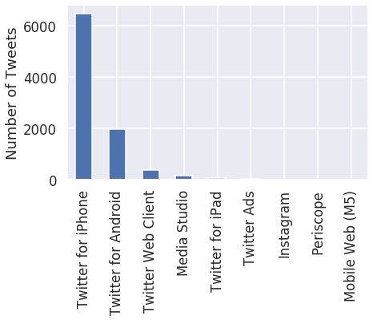

```python
trump['source'].value_counts().plot(kind="bar")
plt.ylabel("Number of Tweets")
```

## Question 4b

Is there a difference between his Tweet behavior across these devices? We will attempt to answer this question in our subsequent analysis.

First, we'll take a look at whether Trump's tweets from an Android come at different times than his tweets from an iPhone. Note that Twitter gives us his tweets in the [UTC timezone](https://www.wikiwand.com/en/List_of_UTC_time_offsets) (notice the `+0000` in the first few tweets)

```python
for t in trump_tweets[0:3]:
    print(t['created_at'])
```

```
Tue Oct 16 16:22:11 +0000 2018
Tue Oct 16 16:18:08 +0000 2018
Tue Oct 16 15:26:33 +0000 2018
```

We'll convert the tweet times to US Eastern Time, the timezone of New York and Washington D.C., since those are the places we would expect the most tweet activity from Trump.

```python
trump['est_time'] = (
    trump['time'].dt.tz_convert("EST") # Convert to Eastern Time
    # If your data frame is, for some reason, not timezone-aware
    # you might need the below two lines instead:
    #  trump['time'].dt.tz_localize("UTC") # Set initial timezone to UTC
    # .trump['time'].dt.tz_convert("EST") # Convert to Eastern Time
)
trump.head()
```

| id | text | retweet_count | favorite_count | source | time | est_time |
| --- | --- | --- | --- | --- | --- | --- |
| 786204978629185536 | PAY TO PLAY POLITICS. \n#CrookedHillary https://t.co/wjsl8ITVvk | 24915 | 42242 | Twitter for iPhone | 2016-10-12 14:00:48+00:00 | 2016-10-12 09:00:48-05:00 |
| 786201435486781440 | Very little pick-up by the dishonest media of incredible information provided by WikiLeaks. So dishonest! Rigged system! | 22609 | 54117 | Twitter for iPhone | 2016-10-12 13:46:43+00:00 | 2016-10-12 08:46:43-05:00 |
| 786189446274248704 | Crooked Hillary Clinton likes to talk about the things she will do but she has been there for 30 years - why didn't she do them? | 18329 | 49885 | Twitter for Android | 2016-10-12 12:59:05+00:00 | 2016-10-12 07:59:05-05:00 |
| 786054986534969344 | Thank you Florida- a MOVEMENT that has never been seen before and will never be seen again. Lets get out &amp;… https://t.co/t9XM9wFDZI | 18789 | 48734 | Twitter for iPhone | 2016-10-12 04:04:47+00:00 | 2016-10-11 23:04:47-05:00 |
| 786007502639038464 | Join me Thursday in Florida &amp; Ohio!\nWest Palm Beach, FL at noon:\nhttps://t.co/jwbZnQhxg9\nCincinnati, OH this 7:30pm:\nhttps://t.co/5w2UhalPIx | 7761 | 19234 | Twitter for iPhone | 2016-10-12 00:56:06+00:00 | 2016-10-11 19:56:06-05:00 |

**What you need to do:**

Add a column called `hour` to the `trump` table which contains the hour of the day as floating point number computed by:

$$ \text{hour} + \frac{\text{minute}}{60} + \frac{\text{second}}{60^2} $$

```python
### BEGIN SOLUTION
trump['strtime'] = trump["est_time"].astype(str)
trump['hours'] = trump["strtime"].str.slice(10,13).astype(float)
trump['minute'] = trump["strtime"].str.slice(14,16).astype(float)
trump['seconds'] =  trump["strtime"].str.slice(17,19).astype(float)
trump['hour'] = trump['hours'] + (trump['minute']/60) + (trump['seconds']/(60**2))
trump.head()
### END SOLUTION
```

| id | text | retweet_count | favorite_count | source | time | est_time | strtime | hours | minute | seconds | hour |
| --- | --- | --- | --- | --- | --- | --- | --- | --- | --- | --- | --- |
| 786204978629185536 | PAY TO PLAY POLITICS. \n#CrookedHillary https://t.co/wjsl8ITVvk | 24915 | 42242 | Twitter for iPhone | 2016-10-12 14:00:48+00:00 | 2016-10-12 09:00:48-05:00 | 2016-10-12 09:00:48-05:00 | 9.0 | 0.0 | 48.0 | 9.013333 |
| 786201435486781440 | Very little pick-up by the dishonest media of incredible information provided by WikiLeaks. So dishonest! Rigged system! | 22609 | 54117 | Twitter for iPhone | 2016-10-12 13:46:43+00:00 | 2016-10-12 08:46:43-05:00 | 2016-10-12 08:46:43-05:00 | 8.0 | 46.0 | 43.0 | 8.778611 |
| 786189446274248704 | Crooked Hillary Clinton likes to talk about the things she will do but she has been there for 30 years - why didn't she do them? | 18329 | 49885 | Twitter for Android | 2016-10-12 12:59:05+00:00 | 2016-10-12 07:59:05-05:00 | 2016-10-12 07:59:05-05:00 | 7.0 | 59.0 | 5.0 | 7.984722 |
| 786054986534969344 | Thank you Florida- a MOVEMENT that has never been seen before and will never be seen again. Lets get out &amp;… https://t.co/t9XM9wFDZI | 18789 | 48734 | Twitter for iPhone | 2016-10-12 04:04:47+00:00 | 2016-10-11 23:04:47-05:00 | 2016-10-11 23:04:47-05:00 | 23.0 | 4.0 | 47.0 | 23.079722 |
| 786007502639038464 | Join me Thursday in Florida &amp; Ohio!\nWest Palm Beach, FL at noon:\nhttps://t.co/jwbZnQhxg9\nCincinnati, OH this 7:30pm:\nhttps://t.co/5w2UhalPIx | 7761 | 19234 | Twitter for iPhone | 2016-10-12 00:56:06+00:00 | 2016-10-11 19:56:06-05:00 | 2016-10-11 19:56:06-05:00 | 19.0 | 56.0 | 6.0 | 19.935000 |

```python
assert np.isclose(trump.loc[690171032150237184]['hour'], 8.93639)
```

## Question 4c

Use this data along with the seaborn `distplot` function to examine the distribution over hours of the day in eastern time that trump tweets on each device for the 2 most commonly used devices. Your plot should look similar to the following.

[figure not shown]

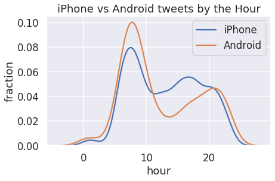

```python
### make your plot here
### BEGIN SOLUTION
trump['device'] = trump["source"].str.replace('Twitter for ','')
iPhone = trump[trump['device']=='iPhone']
Android = trump[trump['device']=='Android']
#trump.head()
axes = sns.distplot(iPhone['hour'], label='iPhone', hist=False)
axes = sns.distplot(Android['hour'], label='Android', hist=False)
axes.legend()
axes.set_xlabel('hour')
axes.set_ylabel('fraction')
axes.set_title('iPhone vs Android tweets by the Hour')

#TODO
### END SOLUTION
```

## Question 4d

According to [this Verge article](https://www.theverge.com/2017/3/29/15103504/donald-trump-iphone-using-switched-android), Donald Trump switched from an Android to an iPhone sometime in March 2017.

Create a figure identical to your figure from 4c, except that you should show the results only from 2016. If you get stuck consider looking at the `year_fraction` function from the next problem.

During the campaign, it was theorized that Donald Trump's tweets from Android were written by him personally, and the tweets from iPhone were from his staff. Does your figure give support to this theory?

```python
trump.head()
```

| id | text | retweet_count | favorite_count | source | time | est_time | strtime | hours | minute | seconds | hour | device |
| --- | --- | --- | --- | --- | --- | --- | --- | --- | --- | --- | --- | --- |
| 786204978629185536 | PAY TO PLAY POLITICS. \n#CrookedHillary https://t.co/wjsl8ITVvk | 24915 | 42242 | Twitter for iPhone | 2016-10-12 14:00:48+00:00 | 2016-10-12 09:00:48-05:00 | 2016-10-12 09:00:48-05:00 | 9.0 | 0.0 | 48.0 | 9.013333 | iPhone |
| 786201435486781440 | Very little pick-up by the dishonest media of incredible information provided by WikiLeaks. So dishonest! Rigged system! | 22609 | 54117 | Twitter for iPhone | 2016-10-12 13:46:43+00:00 | 2016-10-12 08:46:43-05:00 | 2016-10-12 08:46:43-05:00 | 8.0 | 46.0 | 43.0 | 8.778611 | iPhone |
| 786189446274248704 | Crooked Hillary Clinton likes to talk about the things she will do but she has been there for 30 years - why didn't she do them? | 18329 | 49885 | Twitter for Android | 2016-10-12 12:59:05+00:00 | 2016-10-12 07:59:05-05:00 | 2016-10-12 07:59:05-05:00 | 7.0 | 59.0 | 5.0 | 7.984722 | Android |
| 786054986534969344 | Thank you Florida- a MOVEMENT that has never been seen before and will never be seen again. Lets get out &amp;… https://t.co/t9XM9wFDZI | 18789 | 48734 | Twitter for iPhone | 2016-10-12 04:04:47+00:00 | 2016-10-11 23:04:47-05:00 | 2016-10-11 23:04:47-05:00 | 23.0 | 4.0 | 47.0 | 23.079722 | iPhone |
| 786007502639038464 | Join me Thursday in Florida &amp; Ohio!\nWest Palm Beach, FL at noon:\nhttps://t.co/jwbZnQhxg9\nCincinnati, OH this 7:30pm:\nhttps://t.co/5w2UhalPIx | 7761 | 19234 | Twitter for iPhone | 2016-10-12 00:56:06+00:00 | 2016-10-11 19:56:06-05:00 | 2016-10-11 19:56:06-05:00 | 19.0 | 56.0 | 6.0 | 19.935000 | iPhone |

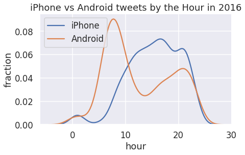

```python
### make your plot here
trump['year'] = trump["strtime"].str.slice(0,4).astype(str)

year16 = trump[trump['year']=='2016']
iPhone16 = year16[year16['device']=='iPhone']
Android16 = year16[year16['device']=='Android']
#trump.head()
axes1 = sns.distplot(iPhone16['hour'], label='iPhone',hist=False)
axes1 = sns.distplot(Android16['hour'], label='Android',hist=False)
axes1.legend()
axes1.set_xlabel('hour')
axes1.set_ylabel('fraction')
axes1.set_title('iPhone vs Android tweets by the Hour in 2016')
### BEGIN SOLUTION
#TODO
### END SOLUTION
```

## Question 5

Let's now look at which device he has used over the entire time period of this dataset.

To examine the distribution of dates we will convert the date to a fractional year that can be plotted as a distribution.

(Code borrowed from https://stackoverflow.com/questions/6451655/python-how-to-convert-datetime-dates-to-decimal-years)

```python
import datetime
def year_fraction(date):
    start = datetime.date(date.year, 1, 1).toordinal()
    year_length = datetime.date(date.year+1, 1, 1).toordinal() - start
    return date.year + float(date.toordinal() - start) / year_length


trump['year'] = trump['time'].apply(year_fraction)
```

```python
trump.head()
```

| id | text | retweet_count | favorite_count | source | time | est_time | strtime | hours | minute | seconds | hour | device | year |
| --- | --- | --- | --- | --- | --- | --- | --- | --- | --- | --- | --- | --- | --- |
| 786204978629185536 | PAY TO PLAY POLITICS. \n#CrookedHillary https://t.co/wjsl8ITVvk | 24915 | 42242 | Twitter for iPhone | 2016-10-12 14:00:48+00:00 | 2016-10-12 09:00:48-05:00 | 2016-10-12 09:00:48-05:00 | 9.0 | 0.0 | 48.0 | 9.013333 | iPhone | 2016.778689 |
| 786201435486781440 | Very little pick-up by the dishonest media of incredible information provided by WikiLeaks. So dishonest! Rigged system! | 22609 | 54117 | Twitter for iPhone | 2016-10-12 13:46:43+00:00 | 2016-10-12 08:46:43-05:00 | 2016-10-12 08:46:43-05:00 | 8.0 | 46.0 | 43.0 | 8.778611 | iPhone | 2016.778689 |
| 786189446274248704 | Crooked Hillary Clinton likes to talk about the things she will do but she has been there for 30 years - why didn't she do them? | 18329 | 49885 | Twitter for Android | 2016-10-12 12:59:05+00:00 | 2016-10-12 07:59:05-05:00 | 2016-10-12 07:59:05-05:00 | 7.0 | 59.0 | 5.0 | 7.984722 | Android | 2016.778689 |
| 786054986534969344 | Thank you Florida- a MOVEMENT that has never been seen before and will never be seen again. Lets get out &amp;… https://t.co/t9XM9wFDZI | 18789 | 48734 | Twitter for iPhone | 2016-10-12 04:04:47+00:00 | 2016-10-11 23:04:47-05:00 | 2016-10-11 23:04:47-05:00 | 23.0 | 4.0 | 47.0 | 23.079722 | iPhone | 2016.778689 |
| 786007502639038464 | Join me Thursday in Florida &amp; Ohio!\nWest Palm Beach, FL at noon:\nhttps://t.co/jwbZnQhxg9\nCincinnati, OH this 7:30pm:\nhttps://t.co/5w2UhalPIx | 7761 | 19234 | Twitter for iPhone | 2016-10-12 00:56:06+00:00 | 2016-10-11 19:56:06-05:00 | 2016-10-11 19:56:06-05:00 | 19.0 | 56.0 | 6.0 | 19.935000 | iPhone | 2016.778689 |

Use the `sns.distplot` to overlay the distributions of the 2 most frequently used web technologies over the years. Your final plot should look like:

[figure not shown]

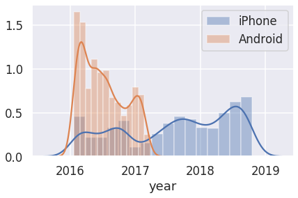

```python
### BEGIN SOLUTION
iPhone = trump[trump['device']=='iPhone']
Android = trump[trump['device']=='Android']
yearlyax = sns.distplot(iPhone['year'], label='iPhone')
yearlyax = sns.distplot(Android['year'], label='Android')
#TODO

yearlyax.legend()

### END SOLUTION
```

## Question 6: Sentiment Analysis

It turns out that we can use the words in Trump's tweets to calculate a measure of the sentiment of the tweet. For example, the sentence "I love America!" has positive sentiment, whereas the sentence "I hate taxes!" has a negative sentiment. In addition, some words have stronger positive / negative sentiment than others: "I love America." is more positive than "I like America."

We will use the [VADER (Valence Aware Dictionary and sEntiment Reasoner)](https://github.com/cjhutto/vaderSentiment) lexicon to analyze the sentiment of Trump's tweets. VADER is a lexicon and rule-based sentiment analysis tool that is specifically attuned to sentiments expressed in social media which is great for our usage.

The VADER lexicon gives the sentiment of individual words. Run the following cell to show the first few rows of the lexicon:

```python
print(''.join(open("vader_lexicon.txt").readlines()[:10]))
```

```
$:	-1.5	0.80623	[-1, -1, -1, -1, -3, -1, -3, -1, -2, -1]
%)	-0.4	1.0198	[-1, 0, -1, 0, 0, -2, -1, 2, -1, 0]
%-)	-1.5	1.43178	[-2, 0, -2, -2, -1, 2, -2, -3, -2, -3]
&-:	-0.4	1.42829	[-3, -1, 0, 0, -1, -1, -1, 2, -1, 2]
&:	-0.7	0.64031	[0, -1, -1, -1, 1, -1, -1, -1, -1, -1]
( '}{' )	1.6	0.66332	[1, 2, 2, 1, 1, 2, 2, 1, 3, 1]
(%	-0.9	0.9434	[0, 0, 1, -1, -1, -1, -2, -2, -1, -2]
('-:	2.2	1.16619	[4, 1, 4, 3, 1, 2, 3, 1, 2, 1]
(':	2.3	0.9	[1, 3, 3, 2, 2, 4, 2, 3, 1, 2]
((-:	2.1	0.53852	[2, 2, 2, 1, 2, 3, 2, 2, 3, 2]
```

## Question 6a

As you can see, the lexicon contains emojis too! The first column of the lexicon is the *token*, or the word itself. The second column is the *polarity* of the word, or how positive / negative it is.

(How did they decide the polarities of these words? What are the other two columns in the lexicon? See the link above.)

Read in the lexicon into a DataFrame called `sent`. The index of the DF should be the tokens in the lexicon. `sent` should have one column: `polarity`: The polarity of each token.

```python
### BEGIN SOLUTION
sent = pd.read_csv('vader_lexicon.txt','\t', usecols = ['token','polarity'], names = ['token','polarity'])
sent.set_index('token', inplace=True)
### END SOLUTION
sent.head()
```

| token | polarity |
| --- | --- |
| $: | -1.5 |
| %) | -0.4 |
| %-) | -1.5 |
| &-: | -0.4 |
| &: | -0.7 |

```python
assert isinstance(sent, pd.DataFrame)
assert sent.shape == (7517, 1)
assert list(sent.index[5000:5005]) == ['paranoids', 'pardon', 'pardoned', 'pardoning', 'pardons']
assert np.allclose(sent['polarity'].head(), [-1.5, -0.4, -1.5, -0.4, -0.7])
```

## Question 6b

Now, let's use this lexicon to calculate the overall sentiment for each of Trump's tweets. Here's the basic idea:

1. For each tweet, find the sentiment of each word.
2. Calculate the sentiment of each tweet by taking the sum of the sentiments of its words.

First, let's lowercase the text in the tweets since the lexicon is also lowercase. Set the `text` column of the `trump` DF to be the lowercased text of each tweet.

```python
### BEGIN SOLUTION
trump['text'] = trump['text'].str.lower()

#TODO
### END SOLUTION
```

```python
assert trump['text'].loc[884740553040175104] == 'working hard to get the olympics for the united states (l.a.). stay tuned!'
```

## Question 6c

Now, let's get rid of punctuation since it'll cause us to fail to match words. Create a new column called `no_punc` in the `trump` DF to be the lowercased text of each tweet with all punctuation replaced by a single space. We consider punctuation characters to be any character that isn't a Unicode word character or a whitespace character. You may want to consult the Python documentation on regexes for this problem.

(Why don't we simply remove punctuation instead of replacing with a space? See if you can figure this out by looking at the tweet data.)

```python
trump.head()
```

| id | text | retweet_count | favorite_count | source | time | est_time | strtime | hours | minute | seconds | hour | device | year |
| --- | --- | --- | --- | --- | --- | --- | --- | --- | --- | --- | --- | --- | --- |
| 786204978629185536 | pay to play politics. \n#crookedhillary https://t.co/wjsl8itvvk | 24915 | 42242 | Twitter for iPhone | 2016-10-12 14:00:48+00:00 | 2016-10-12 09:00:48-05:00 | 2016-10-12 09:00:48-05:00 | 9.0 | 0.0 | 48.0 | 9.013333 | iPhone | 2016.778689 |
| 786201435486781440 | very little pick-up by the dishonest media of incredible information provided by wikileaks. so dishonest! rigged system! | 22609 | 54117 | Twitter for iPhone | 2016-10-12 13:46:43+00:00 | 2016-10-12 08:46:43-05:00 | 2016-10-12 08:46:43-05:00 | 8.0 | 46.0 | 43.0 | 8.778611 | iPhone | 2016.778689 |
| 786189446274248704 | crooked hillary clinton likes to talk about the things she will do but she has been there for 30 years - why didn't she do them? | 18329 | 49885 | Twitter for Android | 2016-10-12 12:59:05+00:00 | 2016-10-12 07:59:05-05:00 | 2016-10-12 07:59:05-05:00 | 7.0 | 59.0 | 5.0 | 7.984722 | Android | 2016.778689 |
| 786054986534969344 | thank you florida- a movement that has never been seen before and will never be seen again. lets get out &amp;… https://t.co/t9xm9wfdzi | 18789 | 48734 | Twitter for iPhone | 2016-10-12 04:04:47+00:00 | 2016-10-11 23:04:47-05:00 | 2016-10-11 23:04:47-05:00 | 23.0 | 4.0 | 47.0 | 23.079722 | iPhone | 2016.778689 |
| 786007502639038464 | join me thursday in florida &amp; ohio!\nwest palm beach, fl at noon:\nhttps://t.co/jwbznqhxg9\ncincinnati, oh this 7:30pm:\nhttps://t.co/5w2uhalpix | 7761 | 19234 | Twitter for iPhone | 2016-10-12 00:56:06+00:00 | 2016-10-11 19:56:06-05:00 | 2016-10-11 19:56:06-05:00 | 19.0 | 56.0 | 6.0 | 19.935000 | iPhone | 2016.778689 |

```python
# Save your regex in punct_re
import string

### BEGIN SOLUTION
#TODO

#regex = re.compile('[^a-zA-Z]')

#trump['no n'] = trump['text'].replace('\n','', regex=True)
#trump['noneya'] = trump['no n'].sub('', 'ab3d*E')
punct_re = r'[^\w\s]'

#punct_re = r'[!?@$%&*);(-/^.…:#]'
#trump['no_punc'] = trump['no n'].apply(remove_punctuations)
trump['no_punc'] = trump['text'].str.replace(punct_re,' ')
#trump['no_punc'] = trump['no n'].str.replace(punct_re,' ')
#trump['no_punc'] = trump['noneya'].str.replace(punct_re,' ')
trump.head()
### END SOLUTION
```

| id | text | retweet_count | favorite_count | source | time | est_time | strtime | hours | minute | seconds | hour | device | year | no_punc |
| --- | --- | --- | --- | --- | --- | --- | --- | --- | --- | --- | --- | --- | --- | --- |
| 786204978629185536 | pay to play politics. \n#crookedhillary https://t.co/wjsl8itvvk | 24915 | 42242 | Twitter for iPhone | 2016-10-12 14:00:48+00:00 | 2016-10-12 09:00:48-05:00 | 2016-10-12 09:00:48-05:00 | 9.0 | 0.0 | 48.0 | 9.013333 | iPhone | 2016.778689 | pay to play politics \n crookedhillary https t co wjsl8itvvk |
| 786201435486781440 | very little pick-up by the dishonest media of incredible information provided by wikileaks. so dishonest! rigged system! | 22609 | 54117 | Twitter for iPhone | 2016-10-12 13:46:43+00:00 | 2016-10-12 08:46:43-05:00 | 2016-10-12 08:46:43-05:00 | 8.0 | 46.0 | 43.0 | 8.778611 | iPhone | 2016.778689 | very little pick up by the dishonest media of incredible information provided by wikileaks so dishonest rigged system |
| 786189446274248704 | crooked hillary clinton likes to talk about the things she will do but she has been there for 30 years - why didn't she do them? | 18329 | 49885 | Twitter for Android | 2016-10-12 12:59:05+00:00 | 2016-10-12 07:59:05-05:00 | 2016-10-12 07:59:05-05:00 | 7.0 | 59.0 | 5.0 | 7.984722 | Android | 2016.778689 | crooked hillary clinton likes to talk about the things she will do but she has been there for 30 years why didn t she do them |
| 786054986534969344 | thank you florida- a movement that has never been seen before and will never be seen again. lets get out &amp;… https://t.co/t9xm9wfdzi | 18789 | 48734 | Twitter for iPhone | 2016-10-12 04:04:47+00:00 | 2016-10-11 23:04:47-05:00 | 2016-10-11 23:04:47-05:00 | 23.0 | 4.0 | 47.0 | 23.079722 | iPhone | 2016.778689 | thank you florida a movement that has never been seen before and will never be seen again lets get out amp https t co t9xm9wfdzi |
| 786007502639038464 | join me thursday in florida &amp; ohio!\nwest palm beach, fl at noon:\nhttps://t.co/jwbznqhxg9\ncincinnati, oh this 7:30pm:\nhttps://t.co/5w2uhalpix | 7761 | 19234 | Twitter for iPhone | 2016-10-12 00:56:06+00:00 | 2016-10-11 19:56:06-05:00 | 2016-10-11 19:56:06-05:00 | 19.0 | 56.0 | 6.0 | 19.935000 | iPhone | 2016.778689 | join me thursday in florida amp ohio \nwest palm beach fl at noon \nhttps t co jwbznqhxg9\ncincinnati oh this 7 30pm \nhttps t co 5w2uhalpix |

```python
trump['no_punc'].loc[894620077634592769]
```

```
'on  purpleheartday i thank all the brave men and women who have sacrificed in battle for this great nation   usa   https   t co qmfdlslp6p'
```

```python
assert isinstance(punct_re, str)
assert re.search(punct_re, 'this') is None
assert re.search(punct_re, 'this is ok') is None
assert re.search(punct_re, 'this is\nok') is None
assert re.search(punct_re, 'this is not ok.') is not None
assert re.search(punct_re, 'this#is#ok') is not None
assert re.search(punct_re, 'this^is ok') is not None
assert trump['no_punc'].loc[800329364986626048] == 'i watched parts of  nbcsnl saturday night live last night  it is a totally one sided  biased show   nothing funny at all  equal time for us '
assert trump['no_punc'].loc[894620077634592769] == 'on  purpleheartday i thank all the brave men and women who have sacrificed in battle for this great nation   usa   https   t co qmfdlslp6p'
# If you fail these tests, you accidentally changed the text column
assert trump['text'].loc[884740553040175104] == 'working hard to get the olympics for the united states (l.a.). stay tuned!'
```

## Question 6d:

Now, let's convert the tweets into what's called a [*tidy format*](https://cran.r-project.org/web/packages/tidyr/vignettes/tidy-data.html) to make the sentiments easier to calculate. Use the `no_punc` column of `trump` to create a table called `tidy_format`. The index of the table should be the IDs of the tweets, repeated once for every word in the tweet. It has two columns:

1. `num`: The location of the word in the tweet. For example, if the tweet was "i love america", then the location of the word "i" is 0, "love" is 1, and "america" is 2.
2. `word`: The individual words of each tweet.

The first few rows of our `tidy_format` table look like:

|  | num | word |
| --- | --- | --- |
| 894661651760377856 | 0 | i |
| 894661651760377856 | 1 | think |
| 894661651760377856 | 2 | senator |
| 894661651760377856 | 3 | blumenthal |
| 894661651760377856 | 4 | should |

**Note that you'll get different results depending on when you pulled in the tweets.** However, you can double check that your tweet with ID `894661651760377856` has the same rows as ours. Our tests don't check whether your table looks exactly like ours.

As usual, try to avoid using any for loops. Our solution uses a chain of 5 methods on the 'trump' DF, albeit using some rather advanced Pandas hacking.

- **Hint 1:** Try looking at the `expand` argument to pandas' `str.split`.
- **Hint 2:** Try looking at the `stack()` method.
- **Hint 3:** Try looking at the `level` parameter of the `reset_index` method.

```python
### BEGIN SOLUTION
tidyformat = trump['no_punc'].str.split(expand=True)
tidyformat1 = tidyformat.stack(dropna=True).to_frame()
tidyformat2 = tidyformat1.reset_index(level = 1,inplace=True)
tidy_format = tidyformat1.rename(columns={'level_1':'num',0:'word'},inplace=True)
tidy_format = tidyformat1
tidy_format.head()
#tidyformat.shape()
#trump['no_']
#tidy_format = str.split
#TODO
### END SOLUTION
```

| id | num | word |
| --- | --- | --- |
| 786204978629185536 | 0 | pay |
| 786204978629185536 | 1 | to |
| 786204978629185536 | 2 | play |
| 786204978629185536 | 3 | politics |
| 786204978629185536 | 4 | crookedhillary |

```python
assert tidy_format.loc[894661651760377856].shape == (27, 2)
assert ' '.join(list(tidy_format.loc[894661651760377856]['word'])) == 'i think senator blumenthal should take a nice long vacation in vietnam where he lied about his service so he can at least say he was there'
```

## Question 6e:

Now that we have this table in the tidy format, it becomes much easier to find the sentiment of each tweet: we can join the table with the lexicon table.

Add a `polarity` column to the `trump` table. The `polarity` column should contain the sum of the sentiment polarity of each word in the text of the tweet.

**Hint** you will need to merge the `tidy_format` and `sent` tables and group the final answer.

```python
### BEGIN SOLUTION
#trump['polarity'] =
polar = tidy_format.reset_index().merge(sent, left_on = 'word', right_on = 'token', how="left").set_index('id')
trump['polarity'] = polar.groupby(['id'])['polarity'].agg(['sum'])
#polar = tidy_format.merge(sent, left_on = 'word', right_on = 'token',)
#= merge(tidy_format, left_on = 'id', right_on = 'id', inner=True)
trump.head()
#trump['polarity'] = merge(tidy_format, left_on = 'id', right_on = 'id')
### END SOLUTION
```

| id | text | retweet_count | favorite_count | source | time | est_time | strtime | hours | minute | seconds | hour | device | year | no_punc | polarity |
| --- | --- | --- | --- | --- | --- | --- | --- | --- | --- | --- | --- | --- | --- | --- | --- |
| 786204978629185536 | pay to play politics. \n#crookedhillary https://t.co/wjsl8itvvk | 24915 | 42242 | Twitter for iPhone | 2016-10-12 14:00:48+00:00 | 2016-10-12 09:00:48-05:00 | 2016-10-12 09:00:48-05:00 | 9.0 | 0.0 | 48.0 | 9.013333 | iPhone | 2016.778689 | pay to play politics \n crookedhillary https t co wjsl8itvvk | 1.0 |
| 786201435486781440 | very little pick-up by the dishonest media of incredible information provided by wikileaks. so dishonest! rigged system! | 22609 | 54117 | Twitter for iPhone | 2016-10-12 13:46:43+00:00 | 2016-10-12 08:46:43-05:00 | 2016-10-12 08:46:43-05:00 | 8.0 | 46.0 | 43.0 | 8.778611 | iPhone | 2016.778689 | very little pick up by the dishonest media of incredible information provided by wikileaks so dishonest rigged system | -6.9 |
| 786189446274248704 | crooked hillary clinton likes to talk about the things she will do but she has been there for 30 years - why didn't she do them? | 18329 | 49885 | Twitter for Android | 2016-10-12 12:59:05+00:00 | 2016-10-12 07:59:05-05:00 | 2016-10-12 07:59:05-05:00 | 7.0 | 59.0 | 5.0 | 7.984722 | Android | 2016.778689 | crooked hillary clinton likes to talk about the things she will do but she has been there for 30 years why didn t she do them | 1.8 |
| 786054986534969344 | thank you florida- a movement that has never been seen before and will never be seen again. lets get out &amp;… https://t.co/t9xm9wfdzi | 18789 | 48734 | Twitter for iPhone | 2016-10-12 04:04:47+00:00 | 2016-10-11 23:04:47-05:00 | 2016-10-11 23:04:47-05:00 | 23.0 | 4.0 | 47.0 | 23.079722 | iPhone | 2016.778689 | thank you florida a movement that has never been seen before and will never be seen again lets get out amp https t co t9xm9wfdzi | 1.5 |
| 786007502639038464 | join me thursday in florida &amp; ohio!\nwest palm beach, fl at noon:\nhttps://t.co/jwbznqhxg9\ncincinnati, oh this 7:30pm:\nhttps://t.co/5w2uhalpix | 7761 | 19234 | Twitter for iPhone | 2016-10-12 00:56:06+00:00 | 2016-10-11 19:56:06-05:00 | 2016-10-11 19:56:06-05:00 | 19.0 | 56.0 | 6.0 | 19.935000 | iPhone | 2016.778689 | join me thursday in florida amp ohio \nwest palm beach fl at noon \nhttps t co jwbznqhxg9\ncincinnati oh this 7 30pm \nhttps t co 5w2uhalpix | 1.2 |

```python
assert np.allclose(trump.loc[744701872456536064, 'polarity'], 8.4)
assert np.allclose(trump.loc[745304731346702336, 'polarity'], 2.5)
assert np.allclose(trump.loc[744519497764184064, 'polarity'], 1.7)
assert np.allclose(trump.loc[894661651760377856, 'polarity'], 0.2)
assert np.allclose(trump.loc[894620077634592769, 'polarity'], 5.4)
# If you fail this test, you dropped tweets with 0 polarity
assert np.allclose(trump.loc[744355251365511169, 'polarity'], 0.0)
```

Now we have a measure of the sentiment of each of his tweets! Note that this calculation is rather basic; you can read over the VADER readme to understand a more robust sentiment analysis.

Now, run the cells below to see the most positive and most negative tweets from Trump in your dataset:

```python
print('Most negative tweets:')
for t in trump.sort_values('polarity').head()['text']:
    print('\n  ', t)
```

```
Most negative tweets:

   it is outrageous that poisonous synthetic heroin fentanyl comes pouring into the u.s. postal system from china. we can, and must, end this now! the senate should pass the stop act – and firmly stop this poison from killing our children and destroying our country. no more delay!

   the rigged russian witch hunt goes on and on as the “originators and founders” of this scam continue to be fired and demoted for their corrupt and illegal activity. all credibility is gone from this terrible hoax, and much more will be lost as it proceeds. no collusion!

   james comey is a proven leaker &amp; liar. virtually everyone in washington thought he should be fired for the terrible job he did-until he was, in fact, fired. he leaked classified information, for which he should be prosecuted. he lied to congress under oath. he is a weak and.....

   this is an illegally brought rigged witch hunt run by people who are totally corrupt and/or conflicted. it was started and paid for by crooked hillary and the democrats. phony dossier, fisa disgrace and so many lying and dishonest people already fired. 17 angry dems? stay tuned!

   where’s the collusion? they made up a phony crime called collusion, and when there was no collusion they say there was obstruction (of a phony crime that never existed). if you fight back or say anything bad about the rigged witch hunt, they scream obstruction!
```

```python
print('Most positive tweets:')
for t in trump.sort_values('polarity', ascending=False).head()['text']:
    print('\n  ', t)
```

```
Most positive tweets:

   congratulations to patrick reed on his great and courageous masters win! when patrick had his amazing win at doral 5 years ago, people saw his great talent, and a bright future ahead. now he is the masters champion!

   my supporters are the smartest, strongest, most hard working and most loyal that we have seen in our countries history. it is a beautiful thing to watch as we win elections and gather support from all over the country. as we get stronger, so does our country. best numbers ever!

   thank you to all of my great supporters, really big progress being made. other countries wanting to fix crazy trade deals. economy is roaring. supreme court pick getting great reviews. new poll says trump, at over 90%, is the most popular republican in history of the party. wow!

   thank you, @wvgovernor jim justice, for that warm introduction. tonight, it was my great honor to attend the “greenbrier classic – salute to service dinner” in west virginia! god bless our veterans. god bless america - and happy independence day to all! https://t.co/v35qvcn8m6

   the republican party had a great night. tremendous voter energy and excitement, and all candidates are those who have a great chance of winning in november. the economy is sooo strong, and with nancy pelosi wanting to end the big tax cuts and raise taxes, why wouldn’t we win?
```

## Question 6g

Plot the distribution of tweet sentiments broken down by whether the text of the tweet contains `nyt` or `fox`. Then in the box below comment on what we observe?

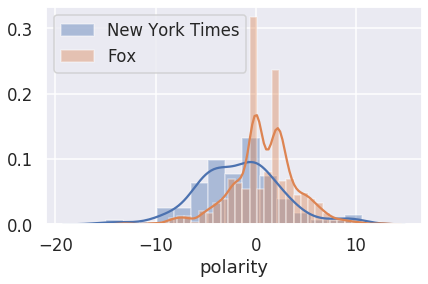

```python
### BEGIN SOLUTION
nyt = trump[trump['no_punc'].str.contains("nyt")]
fox = trump[trump['no_punc'].str.contains("fox")]

journal = sns.distplot(nyt['polarity'], label='New York Times')
journal = sns.distplot(fox['polarity'], label='Fox')
#TODO

journal.legend()
#TODO
### END SOLUTION
```

#### Comment on what you observe:

```python
this = r"""
We see that Fox news has a higher sentiment value attached to it on average than the NYT.
Also, assuming that the y axis is frequency, it shows that he tweets more about fox than nyt.

"""
print(this)
```

```
We see that Fox news has a higher sentiment value attached to it on average than the NYT.
Also, assuming that the y axis is frequency, it shows that he tweets more about fox than nyt.
```

We notice that the president appears to say more positive things about Fox than the New York Times.

```python
tidy_format.head()
```

| id | num | word |
| --- | --- | --- |
| 786204978629185536 | 0 | pay |
| 786204978629185536 | 1 | to |
| 786204978629185536 | 2 | play |
| 786204978629185536 | 3 | politics |
| 786204978629185536 | 4 | crookedhillary |

## Question 7: Engagement

## Question 7a

In this problem, we'll explore which words led to a greater average number of retweets. For example, at the time of this writing, Donald Trump has two tweets that contain the word 'oakland' (tweets 932570628451954688 and 1016609920031117312) with 36757 and 10286 retweets respectively, for an average of 23,521.5.

Find the top 20 most retweeted words. Include only words that appear in at least 25 tweets. As usual, try to do this without any for loops. You can string together ~7 pandas commands and get everything done on one line.

Your `top_20` table should have this format:

| word | retweet_count |
| --- | --- |
| jong | 40675.666667 |
| try | 33937.800000 |
| kim | 32849.595745 |
| un | 32741.731707 |
| maybe | 30473.192308 |

Note that the contents of the table may be different based on how many tweets you pulled and when you did so; focus on the format, not the numbers.

```python
### BEGIN SOLUTION
broken = tidy_format.merge(trump, left_on = 'id', right_on = 'id', how="outer")
thisthat = broken['word'].value_counts()
wordseries = thisthat.to_frame().reset_index()
wordseries.rename(columns={'index':'word','word':'wordcount'},inplace=True)
#wordseries
themmerged = broken.merge(wordseries, left_on = 'word', right_on = 'word')
lessthan25 = themmerged[themmerged['wordcount'] <= 25]
#lessthan25
nowthis = lessthan25.groupby('word')['retweet_count'].agg(['sum'])
#nowthis
top_20 = nowthis.sort_values('sum',ascending = False)
top_20 = top_20.rename(columns={'sum':'retweet_count'})
#keepcountonly = lessthan25.drop_duplicates(subset =["word"], keep = 'first')
#keepcountonly
#therewego
#brokeit = broken.merge(thisthat, left_on = 'word', right_on = 'index')
#brokeit
#nowthis = keepcountonly.groupby('word')['retweet_count'].agg(['sum'])
#nowthis.sort_values('sum',ascending = False)

#top_20 = ... #TODO
### END SOLUTION
```

```python
# Although it can't be guaranteed, it's very likely that some of these words will be in the top 20
# Although this may vary depending on when exactly you pulled your data:
assert 'un'     in top_20.index
assert 'nuclear' in top_20.index
assert 'old'    in top_20.index
assert 'nfl'    in top_20.index
```

[output not shown]

```python
#top_20['retweet_count'].sort_values().plot.barh(figsize=(10, 8));
```

## Question 7b

At some point in time, "kim", "jong" and "un" were apparently really popular in Trump's tweets! It seems like we can conclude that his tweets involving jong are more popular than his other tweets. Or can we?

Consider each of the statements about possible confounding factors below. State whether each statement is true or false and explain. If the statement is true, state whether the confounding factor could have made kim jong un related tweets higher in the list than they should be.

1. We didn't restrict our word list to nouns, so we have unhelpful words like "let" and "any" in our result.
2. We didn't remove hashtags in our text, so we have duplicate words (eg. #great and great).
3. We didn't account for the fact that Trump's follower count has increased over time.
1. True. However, this will not cause "kim", "jong" and "un" to top the list of retweeted words since restricting to nouns does not affect the count of the retweets containing "kim", "jong" and "un".
2. False. We removed hashtags in our text when we removed punctuation.
3. True. This could indeed cause "kim", "jong" and "un" to appear higher on the list than it should have. If his follower count increased over time, we would expect the number of retweets over time to increase as well, regardless of what words are in the tweets. If he just started using the term "fake news" recently, it's likely that those tweets would get more retweets just because he had more followers than before.

## Question 8

Using the `trump` tweets construct an interesting plot describing a property of the data and discuss what you found below.

**Ideas:**

1. How has the sentiment changed with length of the tweets?
2. Does sentiment affect retweet count?
3. Are retweets more negative than regular tweets?
4. Are there any spikes in the number of retweets and do the correspond to world events?
5. *Bonus:* How many Russian twitter bots follow Trump?
6. What terms have an especially positive or negative sentiment?

You can look at other data sources and even tweets.

### Plot:

```python
trump.head()
```

| id | text | retweet_count | favorite_count | source | time | est_time | strtime | hours | minute | seconds | hour | device | year | no_punc | polarity |
| --- | --- | --- | --- | --- | --- | --- | --- | --- | --- | --- | --- | --- | --- | --- | --- |
| 786204978629185536 | pay to play politics. \n#crookedhillary https://t.co/wjsl8itvvk | 24915 | 42242 | Twitter for iPhone | 2016-10-12 14:00:48+00:00 | 2016-10-12 09:00:48-05:00 | 2016-10-12 09:00:48-05:00 | 9.0 | 0.0 | 48.0 | 9.013333 | iPhone | 2016.778689 | pay to play politics \n crookedhillary https t co wjsl8itvvk | 1.0 |
| 786201435486781440 | very little pick-up by the dishonest media of incredible information provided by wikileaks. so dishonest! rigged system! | 22609 | 54117 | Twitter for iPhone | 2016-10-12 13:46:43+00:00 | 2016-10-12 08:46:43-05:00 | 2016-10-12 08:46:43-05:00 | 8.0 | 46.0 | 43.0 | 8.778611 | iPhone | 2016.778689 | very little pick up by the dishonest media of incredible information provided by wikileaks so dishonest rigged system | -6.9 |
| 786189446274248704 | crooked hillary clinton likes to talk about the things she will do but she has been there for 30 years - why didn't she do them? | 18329 | 49885 | Twitter for Android | 2016-10-12 12:59:05+00:00 | 2016-10-12 07:59:05-05:00 | 2016-10-12 07:59:05-05:00 | 7.0 | 59.0 | 5.0 | 7.984722 | Android | 2016.778689 | crooked hillary clinton likes to talk about the things she will do but she has been there for 30 years why didn t she do them | 1.8 |
| 786054986534969344 | thank you florida- a movement that has never been seen before and will never be seen again. lets get out &amp;… https://t.co/t9xm9wfdzi | 18789 | 48734 | Twitter for iPhone | 2016-10-12 04:04:47+00:00 | 2016-10-11 23:04:47-05:00 | 2016-10-11 23:04:47-05:00 | 23.0 | 4.0 | 47.0 | 23.079722 | iPhone | 2016.778689 | thank you florida a movement that has never been seen before and will never be seen again lets get out amp https t co t9xm9wfdzi | 1.5 |
| 786007502639038464 | join me thursday in florida &amp; ohio!\nwest palm beach, fl at noon:\nhttps://t.co/jwbznqhxg9\ncincinnati, oh this 7:30pm:\nhttps://t.co/5w2uhalpix | 7761 | 19234 | Twitter for iPhone | 2016-10-12 00:56:06+00:00 | 2016-10-11 19:56:06-05:00 | 2016-10-11 19:56:06-05:00 | 19.0 | 56.0 | 6.0 | 19.935000 | iPhone | 2016.778689 | join me thursday in florida amp ohio \nwest palm beach fl at noon \nhttps t co jwbznqhxg9\ncincinnati oh this 7 30pm \nhttps t co 5w2uhalpix | 1.2 |

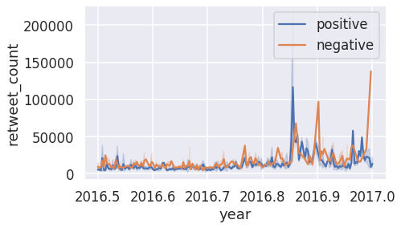

```python
trump['polarity'].astype(float)
sweet = trump[trump['year'] >= 2016.5]
thing = sweet[sweet['year'] <= 2017]
positive = thing[thing['polarity'] > 0]
negative = thing[thing['polarity'] < 0]
polarline = sns.lineplot(x = positive['year'], y= positive['retweet_count'],label = 'positive')
polarline = sns.lineplot(x = negative['year'], y= negative['retweet_count'], label = 'negative')
polarline.legend()
polar
#polar = sns.distplot(x = negative['year'], label='negative', hist=False)
#axes.set_xlabel('hour')
#axes.set_ylabel('fraction')
#axes.set_title('iPhone vs Android tweets by the Hour')
```

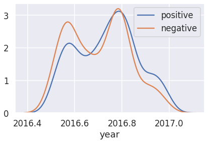

```python
polar = sns.distplot(positive['year'], label='positive',hist = False)
journal = sns.distplot(negative['year'], label='negative', hist = False)
```

### Discussion of Your Plot:

The two graphs above capture the polarity of Trump's tweets over the last half of 2016, when he won the election.

The first graph shows the retweet count by year, for the given sentiment attached to each tweet. In which somewhat of a trend is captured with it being more common than not, for a negative tweet to recieve more retweets than a positive. With there being 1 notable spike of positivity compared to 3 for negative. This graph was cluttered so I created the one directly above.

I found polarity to be an interesting property we added to the data set, as we can more discretely capture the emotion of a tweet. We could also probably attribute some of his success to such emotion displayed.

## Submission

Congrats, you just finished Project 1!